# MGSC 661 Midterm Project

Wenya Cai

2023-10-23

# Libraries and Dataset

## Libraries

```r
library(tidyverse)
library(ggplot2)
library(MASS)
library(corrr)
library(ggcorrplot)
library(car)
library(lmtest)
library(plm)
library(ggpubr)
library(splines)
library(boot)
library(moments)
library(kableExtra)
```

## Dataset

```r
data = read.csv("IMDB_data_Fall_2023.csv")
```

# Data Pre-processing

## Drop Unnecessary Labels

There are three labels in the dataset, so we only keep `movie_id` for simplicity.

```r
drop = c("movie_title","imdb_link")
data = data[,!(names(data) %in% drop)]
```

## Categorical data

To help us better understand the dataset, we take a look at all the categorical data.

List of Categorical Variables

| Variable |
| --- |
| release_month |
| language |
| country |
| maturity_rating |
| distributor |
| director |
| actor1 |
| actor2 |
| actor3 |
| colour_film |
| genres |
| plot_keywords |
| cinematographer |
| production_company |

### Factorize categorical data and more

we pay closer attention to all the predictors.  
`aspect_ratio` seems numeric, but take a closer look - it should be taken as categorical values.  
we also want to see if movies with more genres are likely to have higher scores, since it may indicate richer content.Or, conversely, more genres will lead to lower scores, as it may cause confusion or a lack of focus in the movie’s narrative and theme.

```r
data[] <- lapply(data, function(x) if (is.character(x)) as.factor(x) else x)

data$aspect_ratio <- as.factor(data$aspect_ratio)
categorical_vars <- c(categorical_vars, "aspect_ratio")
data$genres_count = str_count(data$genres, fixed("|")) + 1 #count how many genres are there
attach(data)
```

### Handle Skewness in Categorical Data

Some categorical variables has unbalanced categories distribution.  
To address skewness in categorical data, such as the imbalanced distribution of categories in a maturity_rating variable, it’s effective to consolidate less frequent categories.

```r
table(maturity_rating)
```

```
## maturity_rating
## Approved        G       GP        M    NC-17   Passed       PG    PG-13
##       21       34        2        2        3        4      255      582
##        R    TV-14     TV-G        X
##     1013        3        3        8
```

```r
data <- data %>%
  mutate(
    maturity_rating = case_when(
      maturity_rating == c("PG") ~ "PG",
      maturity_rating == c("PG-13") ~ "PG-13",
      maturity_rating == c("R") ~ "R",
      TRUE ~ "other_ratings"
    )
  )

data <- data %>%
  mutate(
    language = case_when(
      language == c("English") ~ "English",
      TRUE ~ "other_languages"
    )
  )

data <- data %>%
  mutate(
    country = case_when(
      country == c("USA") ~ "USA",
      country == c("UK") ~ "UK",
      TRUE ~ "other_countries"
    )
  )

data <- data %>%
  mutate(
    distributor = case_when(
      distributor == c("Warner Bros.") ~ "Warner Bros.",
      distributor == c("Universal Pictures") ~ "Universal Pictures",
      distributor == c("Paramount Pictures") ~ "Paramount Pictures",
      distributor == c("Twentieth Century Fox") ~ "Twentieth Century Fox",
      distributor == c("Columbia Pictures Corporation") ~ "Columbia Pictures Corporation",
      TRUE ~ "other_distributors"
    )
  )

data <- data %>%
  mutate(
    production_company = case_when(
      production_company == c("Warner Bros.") ~ "Warner Bros.",
      production_company == c("Universal Pictures") ~ "Universal Pictures",
      production_company == c("Paramount Pictures") ~ "Paramount Pictures",
      production_company == c("Twentieth Century Fox") ~ "Twentieth Century Fox",
      production_company == c("Columbia Pictures Corporation") ~ "Columbia Pictures Corporation",
      production_company == c("New Line Cinema") ~ "New Line Cinema",
      TRUE ~ "other_production_companies"
    )
  )

attach(data)
```

Also, those directors with frequent appearances in movies may have a effect on imdb scores. Thus, we add such indicator.

```r
director_counts = table(data$director)
director_75th_percentile = quantile(director_counts, 0.75)
data$director_top25p = ifelse(director_counts[data$director] >= director_75th_percentile, 1, 0)
cine_counts = table(data$cinematographer)
cine_75th_percentile = quantile(cine_counts, 0.75)
data$cine_top25p = ifelse(cine_counts[data$cinematographer] >= cine_75th_percentile , 1, 0)
attach(data)
```

## Mumerical Data

### Handle Skewness in Numerical Data

We want to see the skewness in the numerical data by using `skewness()` function. Based on the skewness value, each column is categorized as “Symmetric”, “Moderately Skewed”, or “Highly Skewed”.  
The variables listed below exhibit the highest skewness and therefore require careful consideration when used as predictors in our model. This is because highly skewed features can potentially bias the model’s performance, leading to inaccurate predictions.

```r
skewness_values = c()
skewness_degrees = c()
num_columns = sapply(data, is.numeric)
for (column in names(data[, num_columns])) {
  skew_value <- round(skewness(data[[column]]),2)
  if (skew_value >= -0.5 && skew_value <= 0.5) {
    skew_degree <- "Symmetric"
  } else if (skew_value > 0.5 && skew_value <= 1 || skew_value < -0.5 && skew_value >= -1) {
    skew_degree <- "Moderated Skewed"
  } else if (skew_value < -1 || skew_value > 1) {
    skew_degree <- "Highly Skewed"
  }
  skewness_values <- c(skewness_values, skew_value)
  skewness_degrees <- c(skewness_degrees, skew_degree)
}
skewness_results <- data.frame(
  Column = names(data[, num_columns]),
  Skewness = skewness_values,
  Skewness_Degree = skewness_degrees
)

skewness_results_abs <- skewness_results[order(abs(skewness_results$Skewness), decreasing = TRUE), ]
skewness_results_abs=skewness_results_abs %>% rename("Abs Skewness" = Skewness)

head(skewness_results_abs,5) %>%
  knitr::kable("html", caption = "Top Skewed Numerical Columns")
```

Top Skewed Numerical Columns

|  | Column | Abs Skewness | Skewness_Degree |
| --- | --- | --- | --- |
| 9 | actor2_star_meter | 27.60 | Highly Skewed |
| 8 | actor1_star_meter | 23.29 | Highly Skewed |
| 7 | nb_news_articles | 18.62 | Highly Skewed |
| 10 | actor3_star_meter | 16.30 | Highly Skewed |
| 25 | movie_meter_IMDBpro | 14.54 | Highly Skewed |

Thus, we do a log transformation to reduce the impact of those highly skewed variables. Since `nb_news_article` has 0 in it, we need to log transform `nb_news_article`+1 to avoid getting negative infinity.

```r
data$movie_meter_IMDBpro = log10(data$movie_meter_IMDBpro)
data$actor1_star_meter = log10(data$actor1_star_meter)
data$actor2_star_meter = log10(data$actor2_star_meter)
data$actor3_star_meter = log10(data$actor3_star_meter)
data$nb_news_articles = log10(data$nb_news_articles+1)
data$movie_budget = log10(data$movie_budget)
attach(data)
```

# Feature Selection and Model Building

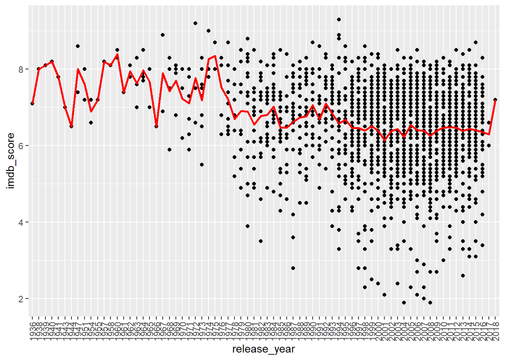

```r
data1 = data
data1$release_year <- as.factor(data$release_year)
ggplot(data1, aes(x=release_year,y=imdb_score)) + geom_point() + stat_summary(fun=mean, geom="line", aes(group=1), color="red", size=1) + theme(axis.text.x = element_text(angle = 90, vjust = 0.5, hjust=1))
```

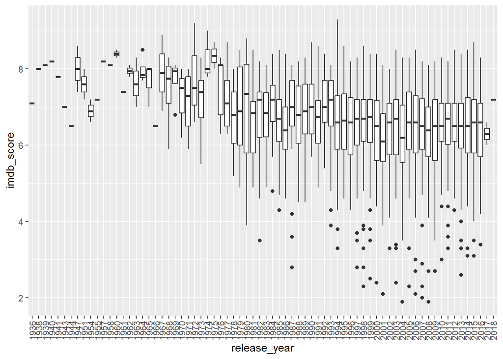

```r
ggplot(data1, aes(x=release_year, y=imdb_score)) +
  geom_boxplot() +
  theme(axis.text.x = element_text(angle = 90, vjust = 0.5, hjust=1))
```

from the above graph, there seems like a relationship between `imdb_score` and `release_year`. Older films tend to have higher scores. Repeat the same process to the rest of the variables.

Drop `release_day`, `release_month` in our model since there’s no visible relationship after inspection.  
We also drop `genres` as we will be using dummified genre predictors, and drop names of actors as we will use star meter from IMDB to measure their impact. `plot_keywords` contains too much information, we will disregard it for now.

## Linear Regression

We first include all the predictors we found possibly significant.

```r
reg = lm(imdb_score ~ movie_budget+release_year+duration+language+country+maturity_rating+aspect_ratio+distributor+nb_news_articles+director_top25p+actor1_star_meter+actor2_star_meter+actor3_star_meter+colour_film+nb_faces+action+adventure+scifi+thriller+musical+romance+western+sport+horror+drama+war+animation+crime+movie_meter_IMDBpro+production_company+cine_top25p+genres_count)
```

### Stepwise Variable Selection for Linear Regression

To identify the model that best balances goodness-of-fit with simplicity, we use stepwise Akaike Information Criterion (AIC) method.

```r
stepAIC(reg,trace = FALSE)
```

```
##
## Call:
## lm(formula = imdb_score ~ movie_budget + release_year + duration +
##     language + country + maturity_rating + nb_news_articles +
##     director_top25p + actor1_star_meter + colour_film + nb_faces +
##     action + musical + romance + western + sport + horror + drama +
##     animation + crime + movie_meter_IMDBpro + cine_top25p)
##
## Coefficients:
##             (Intercept)             movie_budget             release_year
##                38.94217                 -0.47142                 -0.01412
##                duration  languageother_languages                countryUK
##                 0.01086                  0.77526                  0.21450
##              countryUSA        maturity_ratingPG     maturity_ratingPG-13
##                -0.10350                  0.19770                  0.17156
##        maturity_ratingR         nb_news_articles          director_top25p
##                 0.35443                  0.20968                  0.13191
##       actor1_star_meter         colour_filmColor                 nb_faces
##                -0.04436                 -0.39225                 -0.03132
##                  action                  musical                  romance
##                -0.25775                 -0.14771                 -0.09521
##                 western                    sport                   horror
##                 0.21849                  0.20677                 -0.48065
##                   drama                animation                    crime
##                 0.43327                  0.96405                  0.08999
##     movie_meter_IMDBpro              cine_top25p
##                -0.65146                  0.11315
```

This provide us with a foundation model to further fine-tune.

```r
lreg = lm(imdb_score ~  movie_budget + release_year + duration +
    language + country + maturity_rating + nb_news_articles +
    director_top25p + actor1_star_meter + colour_film + nb_faces +
    action + musical + romance + western + sport + horror + drama +
    animation + crime + movie_meter_IMDBpro + cine_top25p)
```

### Linearity Test

We use Residual Plots.

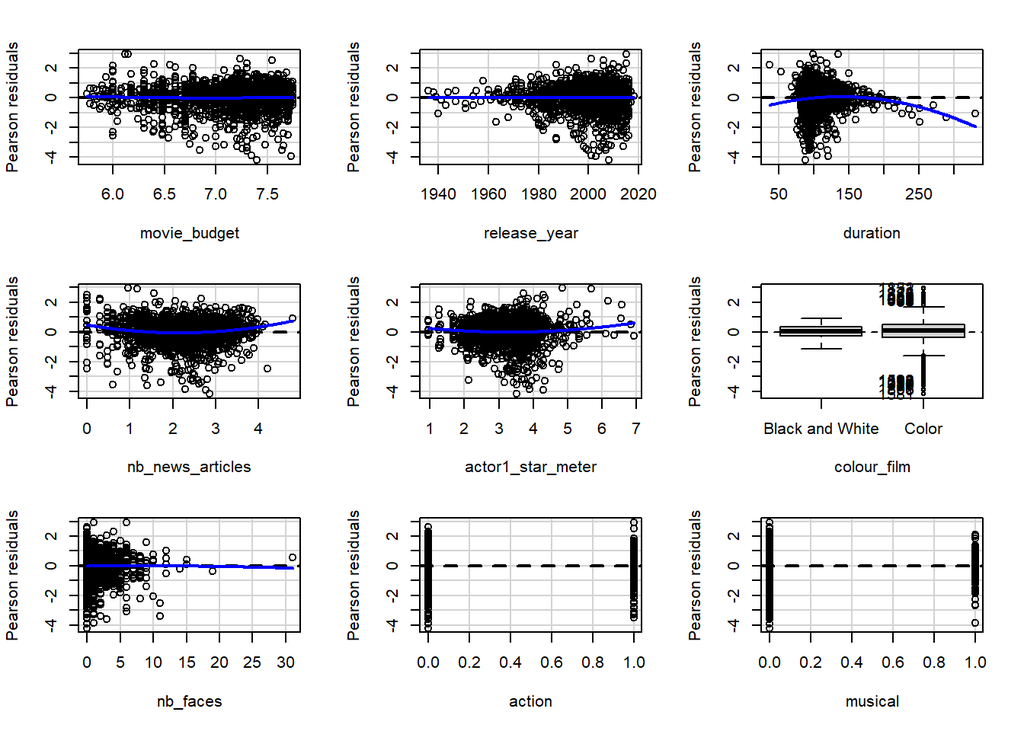

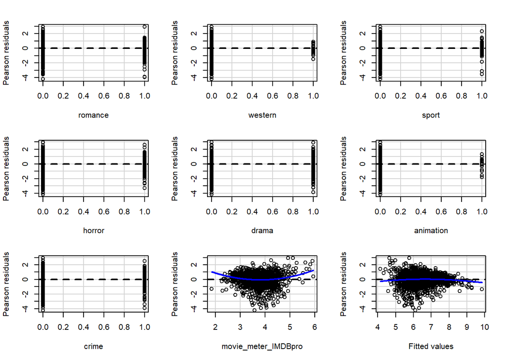

```
##                     Test stat Pr(>|Test stat|)
## movie_budget           0.9779         0.328230
## release_year          -0.0321         0.974397
## duration              -4.5909        4.703e-06 ***
## nb_news_articles       5.4096        7.112e-08 ***
## actor1_star_meter      2.6039         0.009288 **
## colour_film
## nb_faces              -0.2514         0.801544
## action                 0.1821         0.855532
## musical                0.6418         0.521105
## romance               -0.6767         0.498704
## western                0.2366         0.812959
## sport                 -0.2235         0.823135
## horror                -0.3729         0.709297
## drama                 -0.0759         0.939513
## animation             -0.6134         0.539655
## crime                  0.7910         0.429061
## movie_meter_IMDBpro    6.6316        4.314e-11 ***
## Tukey test            -2.3672         0.017922 *
## ---
## Signif. codes:  0 '***' 0.001 '**' 0.01 '*' 0.05 '.' 0.1 ' ' 1
```

```r
res_plots <- residualPlots(lreg)
```

```r
# Print the test statistics
print(res_plots)
```

```
##                       Test stat Pr(>|Test stat|)
## movie_budget         0.97793595     3.282303e-01
## release_year        -0.03209871     9.743967e-01
## duration            -4.59086886     4.702679e-06
## nb_news_articles     5.40963929     7.112469e-08
## actor1_star_meter    2.60392036     9.288102e-03
## colour_film                  NA               NA
## nb_faces            -0.25138508     8.015435e-01
## action               0.18208881     8.555324e-01
## musical              0.64176214     5.211049e-01
## romance             -0.67665997     4.987040e-01
## western              0.23664373     8.129587e-01
## sport               -0.22354495     8.231354e-01
## horror              -0.37285646     7.092968e-01
## drama               -0.07589233     9.395127e-01
## animation           -0.61344504     5.396554e-01
## crime                0.79096845     4.290610e-01
## movie_meter_IMDBpro  6.63159236     4.313568e-11
## Tukey test          -2.36722895     1.792184e-02
```

Tuckey test has very small p value, thus the model is unlikely to be linear.  
We select predictors with large p value, more specifically, p value > 0.1, and consider them likely linear, and the rest is otherwise.  
In this case, `duration`,`nb_news_articles`,`actor1_star_meter`, and `movie_meter_IMDBpro` are likely not linear.

## Non-linear Regression

As mentioned above, `duration`,`nb_news_articles`,`actor1_star_meter`, and `movie_meter_IMDBpro` are not likely linear predictors.  
They are all significant predictors with low p-values.

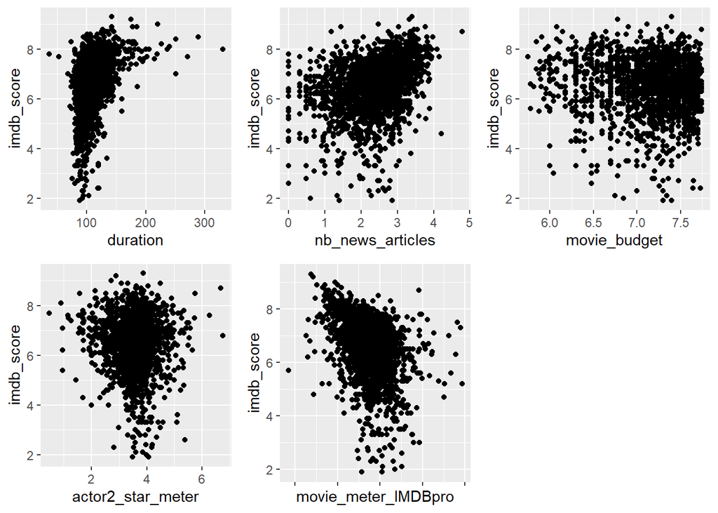

```r
pd = ggplot(data, aes(x=duration,y=imdb_score)) + geom_point()
pn = ggplot(data, aes(x=nb_news_articles,y=imdb_score)) + geom_point()
pa = ggplot(data, aes(x=movie_budget,y=imdb_score)) + geom_point()
pan = ggplot(data, aes(x=actor2_star_meter,y=imdb_score)) + geom_point()
pm = ggplot(data, aes(x=movie_meter_IMDBpro,y=imdb_score)) + geom_point()
ggarrange( pd, pn,pa,pan,pm + rremove("x.text"),
          ncol = 3, nrow = 2)
```

We try polynomials first. We test up to d=5 for each variable.

```r
set.seed(661)
min_mse = Inf
min_i = 0
min_j = 0
min_k = 0
min_l = 0
for (i in 1:5) {
  for (j in 1:5){
    for (k in 1:5) {
      for(l in 1:5){
            fit=glm(imdb_score ~  movie_budget + release_year  +
    language + country + maturity_rating  +
    director_top25p + colour_film + nb_faces +
    action + musical + romance + western + sport + horror + drama +
    animation + crime + cine_top25p +
              poly(actor1_star_meter,i) + poly(duration,j) + poly(nb_news_articles,k) + poly(movie_meter_IMDBpro,l) ,data = data)

            mse_result =cv.glm(fit, K=10,data = data)$delta[1]
            if (mse_result < min_mse) {
              min_mse = mse_result
              min_i = i
              min_j = j
              min_k = k
              min_l = l

          }
        }
    }
  }
 }

min_mse
```

```
## [1] 0.6216043
```

```r
min_i
```

```
## [1] 5
```

```r
min_j
```

```
## [1] 2
```

```r
min_k
```

```
## [1] 2
```

```r
min_l
```

```
## [1] 4
```

```r
model = lm(imdb_score ~  movie_budget + release_year  +
    language + country + maturity_rating  +
    director_top25p + colour_film + nb_faces +
    action + musical + romance + western + sport + horror + drama +
    animation + crime + cine_top25p +
              poly(actor1_star_meter,5) + poly(duration,2) + poly(nb_news_articles,2) + poly(movie_meter_IMDBpro,4),data = data)
```

# Model Fine Tuning

First, we conduct visual funnel test.

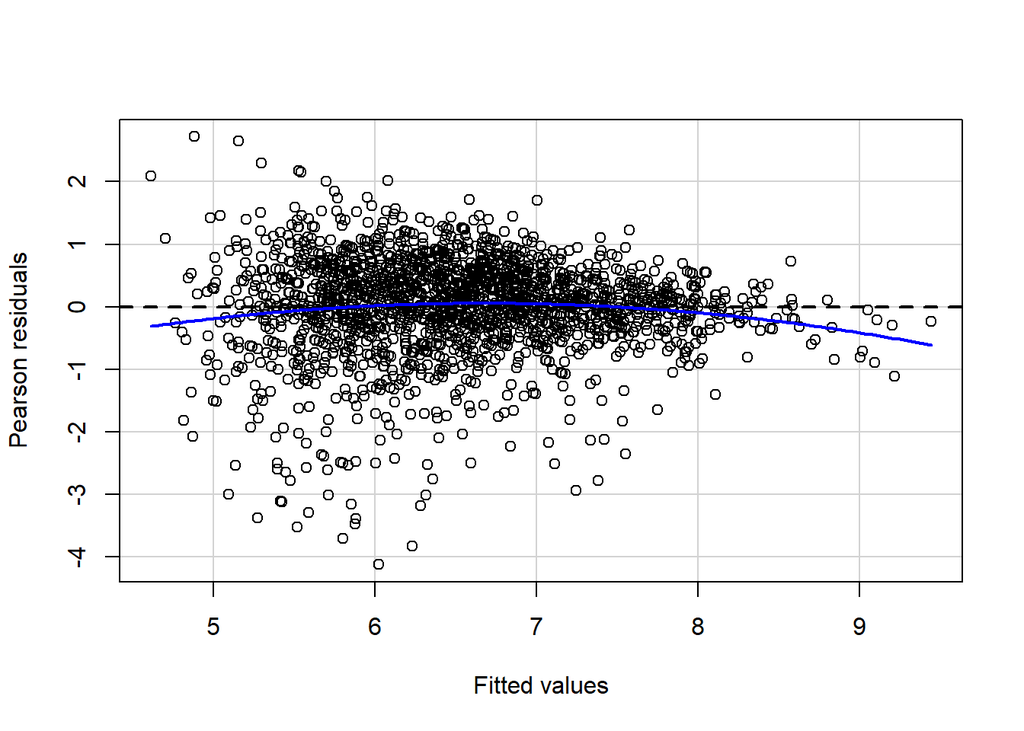

```r
residualPlot(model)
```

Looks like a funnel shape, suggesting Heteroskedasticity. To double check, we further conduct a NCV test. Note that we are using `lm()` instead of `glm()` as `ncvTest()` only consider the former.

```r
ncvTest(model)
```

```
## Non-constant Variance Score Test
## Variance formula: ~ fitted.values
## Chisquare = 207.6298, Df = 1, p = < 2.22e-16
```

p value is way smaller than threshold 0.05, further confirming Heteroskedasticity. We need to correct Heteroskedasticity errors.

```r
coeftest(model, vcov=vcovHC(model, type="HC1"))
```

```
##
## t test of coefficients:
##
##                                  Estimate  Std. Error  t value  Pr(>|t|)
## (Intercept)                    40.4467133   3.9951440  10.1240 < 2.2e-16 ***
## movie_budget                   -0.4648426   0.0548527  -8.4744 < 2.2e-16 ***
## release_year                   -0.0153087   0.0020937  -7.3118 3.869e-13 ***
## languageother_languages         0.7422829   0.1344459   5.5211 3.834e-08 ***
## countryUK                       0.1737953   0.0875277   1.9856 0.0472212 *
## countryUSA                     -0.1215808   0.0741862  -1.6389 0.1014084
## maturity_ratingPG               0.1574932   0.1341570   1.1739 0.2405635
## maturity_ratingPG-13            0.1306825   0.1429676   0.9141 0.3607962
## maturity_ratingR                0.2932993   0.1363984   2.1503 0.0316566 *
## director_top25p                 0.1258365   0.0430670   2.9219 0.0035205 **
## colour_filmColor               -0.3828905   0.0641521  -5.9685 2.851e-09 ***
## nb_faces                       -0.0320487   0.0096049  -3.3367 0.0008642 ***
## action                         -0.2772118   0.0537964  -5.1530 2.831e-07 ***
## musical                        -0.1362320   0.0781987  -1.7421 0.0816486 .
## romance                        -0.1021975   0.0433710  -2.3564 0.0185565 *
## western                         0.1349962   0.0945115   1.4284 0.1533536
## sport                           0.2093131   0.0865316   2.4189 0.0156603 *
## horror                         -0.4534894   0.0682737  -6.6422 4.024e-11 ***
## drama                           0.4172337   0.0459541   9.0794 < 2.2e-16 ***
## animation                       1.0426420   0.1896340   5.4982 4.357e-08 ***
## crime                           0.1205958   0.0462539   2.6073 0.0091988 **
## cine_top25p                     0.1300788   0.0431779   3.0126 0.0026243 **
## poly(actor1_star_meter, 5)1    -0.7114731   0.8201839  -0.8675 0.3858023
## poly(actor1_star_meter, 5)2     1.6071650   0.7106595   2.2615 0.0238405 *
## poly(actor1_star_meter, 5)3     1.9248254   0.6599660   2.9166 0.0035809 **
## poly(actor1_star_meter, 5)4    -0.2689803   0.6330386  -0.4249 0.6709552
## poly(actor1_star_meter, 5)5    -3.3309391   0.7198517  -4.6273 3.956e-06 ***
## poly(duration, 2)1              9.6203370   0.9472122  10.1565 < 2.2e-16 ***
## poly(duration, 2)2             -3.4555565   0.9470725  -3.6487 0.0002707 ***
## poly(nb_news_articles, 2)1      7.5504713   1.1692934   6.4573 1.351e-10 ***
## poly(nb_news_articles, 2)2      1.4491250   1.1455802   1.2650 0.2060375
## poly(movie_meter_IMDBpro, 4)1 -12.8776340   1.1410559 -11.2857 < 2.2e-16 ***
## poly(movie_meter_IMDBpro, 4)2   4.4926594   1.0045538   4.4723 8.197e-06 ***
## poly(movie_meter_IMDBpro, 4)3   3.3607900   0.8157923   4.1197 3.958e-05 ***
## poly(movie_meter_IMDBpro, 4)4  -1.8134937   0.7740191  -2.3430 0.0192345 *
## ---
## Signif. codes:  0 '***' 0.001 '**' 0.01 '*' 0.05 '.' 0.1 ' ' 1
```

we may consider remove `western`. Use 10-fold to check the change in MSE.

```r
set.seed(661)
m1 = glm( imdb_score ~  movie_budget + release_year  +
    language + country + maturity_rating  +
    director_top25p + colour_film + nb_faces +
    action + musical + romance + western + sport + horror + drama +
    animation + crime + cine_top25p +
              poly(actor1_star_meter,5) + poly(duration,2) + poly(nb_news_articles,2) + poly(movie_meter_IMDBpro,4),data = data)

m2 =  glm(imdb_score ~  movie_budget + release_year  +
    language + country + maturity_rating  +
    director_top25p + colour_film + nb_faces +
    action + musical + romance + sport + horror + drama +
    animation + crime + cine_top25p +
              poly(actor1_star_meter,5) + poly(duration,2) + poly(nb_news_articles,2) + poly(movie_meter_IMDBpro,4),data = data)
cv.glm(m1, K=10,data = data)$delta[1]
```

```
## [1] 0.6237006
```

```r
cv.glm(m2, K=10,data = data)$delta[1]
```

```
## [1] 0.6196928
```

We decided to remove it, as MSE decreased after the removal.

## Outliers

We run a bonferroni test, since the size of data may lead to difficulties of visual test on outliers.

```r
outlierTest(m2)
```

```
##       rstudent unadjusted p-value Bonferroni p
## 1581 -5.329171         9.8662e-08   0.00019042
## 395  -4.965765         6.8431e-07   0.00132070
## 1806 -4.793280         1.6408e-06   0.00316670
## 316  -4.573708         4.7917e-06   0.00924790
## 191  -4.500128         6.7913e-06   0.01310700
## 599  -4.373304         1.2238e-05   0.02361900
## 989  -4.369787         1.2437e-05   0.02400300
## 1255 -4.262162         2.0246e-05   0.03907500
```

We should remove the outliers and see model performance again.

```r
set.seed(661)
data_cleaned = data[-c(1581,395,1806,316,191,989,599,1255)]
m2 =  glm(imdb_score ~  movie_budget + release_year  +
    language + country + maturity_rating  +
    director_top25p + colour_film + nb_faces +
    action + musical + romance + sport + horror + drama +
    animation + crime + cine_top25p +
              poly(actor1_star_meter,5) + poly(duration,2) + poly(nb_news_articles,2) + poly(movie_meter_IMDBpro,4),data = data)

m3  =  glm(imdb_score ~  movie_budget + release_year  +
    language + country + maturity_rating  +
    director_top25p + colour_film + nb_faces +
    action + musical + romance + sport + horror + drama +
    animation + crime + cine_top25p +
              poly(actor1_star_meter,5) + poly(duration,2) + poly(nb_news_articles,2) + poly(movie_meter_IMDBpro,4),data = data_cleaned)
cv.glm(m2, K=10,data = data)$delta[1]
```

```
## [1] 0.6231655
```

```r
cv.glm(m3, K=10,data = data_cleaned)$delta[1]
```

```
## [1] 0.6196928
```

The MSE decreased, so we move on with `data_cleaned`.

## Handling Collinearity

### Collinearity Matrix

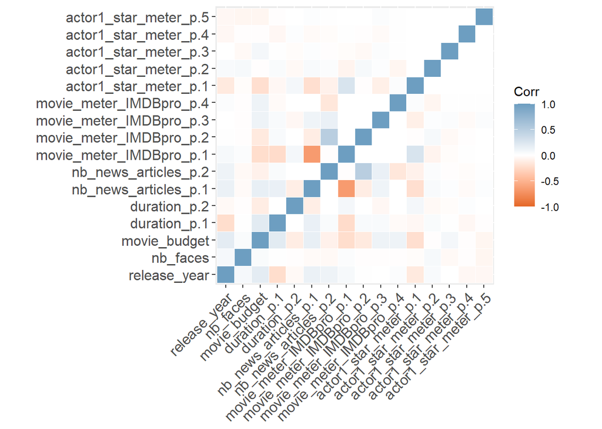

```r
num_vars <- c("release_year", "nb_faces","movie_budget")

num_data <- data_cleaned[, num_vars]

# Applying polynomial transformations
num_data$duration_p <- poly(data_cleaned$duration, 2)
num_data$nb_news_articles_p <- poly(data_cleaned$nb_news_articles, 2)
num_data$movie_meter_IMDBpro_p <- poly(data_cleaned$movie_meter_IMDBpro, 4)
num_data$actor1_star_meter_p <- poly(data_cleaned$actor1_star_meter, 5)


corr_matrix <- cor(num_data)
ggcorrplot(corr_matrix,
           colors = c("#E46726", "white", "#6D9EC1"),
           outline.color = "white",
           ggtheme = ggplot2::theme_gray)
```

poly(`movie_meter_IMDBpro`,1) seems to have high correlation with poly(`nb_news_articles`,1).

```r
corr_matrix["movie_meter_IMDBpro_p.1", "nb_news_articles_p.1"]
```

```
## [1] -0.6598977
```

After further inspection, the correlation between these two is above threshold -0.8 to cause collinearity, according to Rule of thumb.

### Variance inflation factors

To double check collinearity, we use Variance inflation factors(VIF) to measures how variance increases with the addition of a variable.

```r
vif(m3)
```

```
##                                  GVIF Df GVIF^(1/(2*Df))
## movie_budget                 1.663015  1        1.289579
## release_year                 1.756411  1        1.325296
## language                     1.185508  1        1.088810
## country                      1.214888  2        1.049867
## maturity_rating              1.882372  3        1.111180
## director_top25p              1.181942  1        1.087172
## colour_film                  1.078364  1        1.038443
## nb_faces                     1.070418  1        1.034610
## action                       1.263357  1        1.123992
## musical                      1.082996  1        1.040671
## romance                      1.173069  1        1.083083
## sport                        1.100864  1        1.049221
## horror                       1.322962  1        1.150201
## drama                        1.483066  1        1.217812
## animation                    1.134366  1        1.065066
## crime                        1.232607  1        1.110228
## cine_top25p                  1.227553  1        1.107950
## poly(actor1_star_meter, 5)   1.347803  5        1.030298
## poly(duration, 2)            1.679597  2        1.138417
## poly(nb_news_articles, 2)    3.067615  2        1.323428
## poly(movie_meter_IMDBpro, 4) 3.426171  4        1.166410
```

No visible collinearity since VIF < 4 for all variables.

## Re-Adjust polynomial degress

now, since we make changes to the model predictors, we may need to consider re-run the for loop and adjust polynomial degrees.

```r
set.seed(661)
data_cleaned = data[-c(1581,395,1806,316,191,989,599,1255)]
min_mse = Inf
min_i = 0
min_j = 0
min_k = 0
min_l = 0
for (i in 1:5) {
  for (j in 1:5){
    for (k in 1:5) {
      for(l in 1:5){
            fit=glm(imdb_score ~  movie_budget + release_year  +
    language + country + maturity_rating  +
    director_top25p + colour_film + nb_faces +
    action + musical + romance + sport + horror + drama +
    animation + crime + cine_top25p +
              poly(actor1_star_meter,i) + poly(duration,j) + poly(nb_news_articles,k) + poly(movie_meter_IMDBpro,l),data = data_cleaned)

            mse_result =cv.glm(fit, K=10,data = data)$delta[1]
            if (mse_result < min_mse) {
              min_mse = mse_result
              min_i = i
              min_j = j
              min_k = k
              min_l = l
              }

        }
    }
  }
 }

min_mse
```

```
## [1] 0.6216749
```

```r
min_i
```

```
## [1] 5
```

```r
min_j
```

```
## [1] 2
```

```r
min_k
```

```
## [1] 2
```

```r
min_l
```

```
## [1] 4
```

Fortunately, the result of optimal polynomial degrees is still the same, so we move on with `m3`.

```r
m3  =  glm(imdb_score ~  movie_budget + release_year  +
    language + country + maturity_rating  +
    director_top25p + colour_film + nb_faces +
    action + musical + romance + sport + horror + drama +
    animation + crime + cine_top25p +
              poly(actor1_star_meter,5) + poly(duration,2) + poly(nb_news_articles,2) + poly(movie_meter_IMDBpro,4),data = data_cleaned)
```

# Prediction on Test Data

## Pre-process test data

```r
test_data = read.csv("test_data_IMDB_Fall_2023.csv")
test_data <- test_data %>%
  mutate(
    maturity_rating = case_when(
      maturity_rating == c("PG") ~ "PG",
      maturity_rating == c("PG-13") ~ "PG-13",
      maturity_rating == c("R") ~ "R",
      TRUE ~ "other_ratings"
    )
  )

test_data <- test_data %>%
  mutate(
    language = case_when(
      language == c("English") ~ "English",
      TRUE ~ "other_languages"
    )
  )

test_data <- test_data %>%
  mutate(
    country = case_when(
      country == c("United States") ~ "USA",
      country == c("United Kingdom") ~ "UK",
      TRUE ~ "other_countries"
    )
  )

test_data <- test_data %>%
  mutate(
    distributor = case_when(
      distributor == c("Warner Bros.") ~ "Warner Bros.",
      distributor == c("Universal Pictures") ~ "Universal Pictures",
      distributor == c("Paramount Pictures") ~ "Paramount Pictures",
      distributor == c("Twentieth Century Fox") ~ "Twentieth Century Fox",
      distributor == c("Columbia Pictures Corporation") ~ "Columbia Pictures Corporation",
      TRUE ~ "other_distributors"
    )
  )

test_data <- test_data %>%
  mutate(
    production_company = case_when(
      production_company == c("Warner Bros.") ~ "Warner Bros.",
      production_company == c("Universal Pictures") ~ "Universal Pictures",
      production_company == c("Paramount Pictures") ~ "Paramount Pictures",
      production_company == c("Twentieth Century Fox") ~ "Twentieth Century Fox",
      production_company == c("Columbia Pictures Corporation") ~ "Columbia Pictures Corporation",
      production_company == c("New Line Cinema") ~ "New Line Cinema",
      TRUE ~ "other_production_companies"
    )
  )


test_data$director_top25p <- ifelse(
  !is.na(director_counts[test_data$director]) &
  test_data$director %in% names(director_counts) &
  director_counts[test_data$director] >= director_75th_percentile,
  1,
  0
)
test_data$cine_top25p <- ifelse(
  !is.na(cine_counts[test_data$cinematographer]) &
  test_data$cinematographer %in% names(cine_counts) &
  cine_counts[test_data$cinematographer] >= cine_75th_percentile,
  1,
  0
)

test_data$movie_meter_IMDBpro = log10(test_data$movie_meter_IMDBpro)
test_data$actor1_star_meter = log10(test_data$actor1_star_meter)
test_data$actor2_star_meter = log10(test_data$actor2_star_meter)
test_data$actor3_star_meter = log10(test_data$actor3_star_meter)
test_data$nb_news_articles = log10(test_data$nb_news_articles+1)
test_data$movie_budget= log10(test_data$movie_budget)
```

## Fit the model

```r
m3  =  glm(imdb_score ~  movie_budget + release_year  +
    language + country + maturity_rating  +
    director_top25p + colour_film + nb_faces +
    action + musical + romance + sport + horror + drama +
    animation + crime + cine_top25p +
              poly(actor1_star_meter,5) + poly(duration,2) + poly(nb_news_articles,2) + poly(movie_meter_IMDBpro,4),data = data_cleaned)
col_names <- c("release_year", "language", "country", "maturity_rating", "director_top25p", "colour_film",
  "nb_faces", "action", "musical", "romance", "sport", "horror", "drama", "animation", "crime",
  "cine_top25p", "movie_budget", "duration", "nb_news_articles",
  "movie_meter_IMDBpro", "actor1_star_meter")

for (i in 1:12){
  values <- test_data[i, col_names]
values$movie_budget <- as.numeric(values$movie_budget)
print(predict(m3, newdata = values))
}
```

```
##        1
## 5.389376
##        2
## 6.110026
##        3
## 5.809817
##        4
## 7.061949
##        5
## 6.733779
##        6
## 5.812208
##        7
## 6.397571
##        8
## 6.872417
##        9
## 6.551642
##       10
## 6.184447
##       11
## 6.647781
##       12
## 7.093746
```